# HW8

Brendan Graham

March 19, 2016

Using the classical decomposition technique from class, I fit an ARMA(3,2) model to the residuals of my regression. This gives me

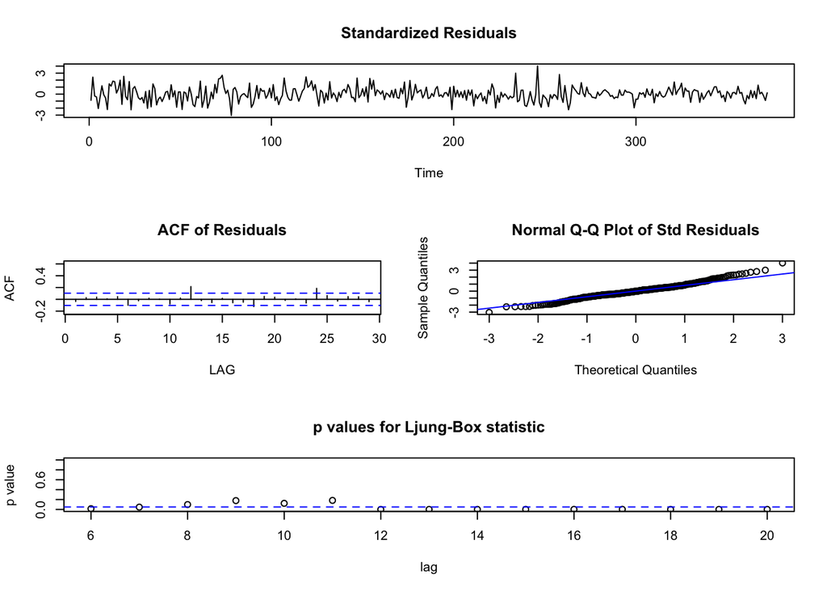

[output not shown]

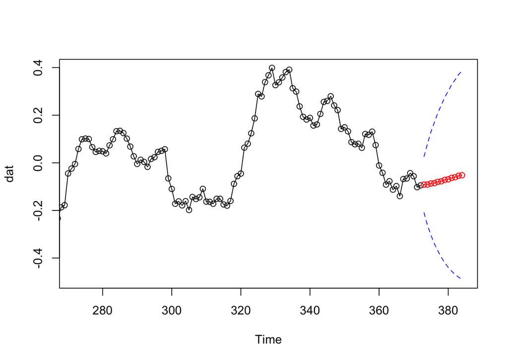

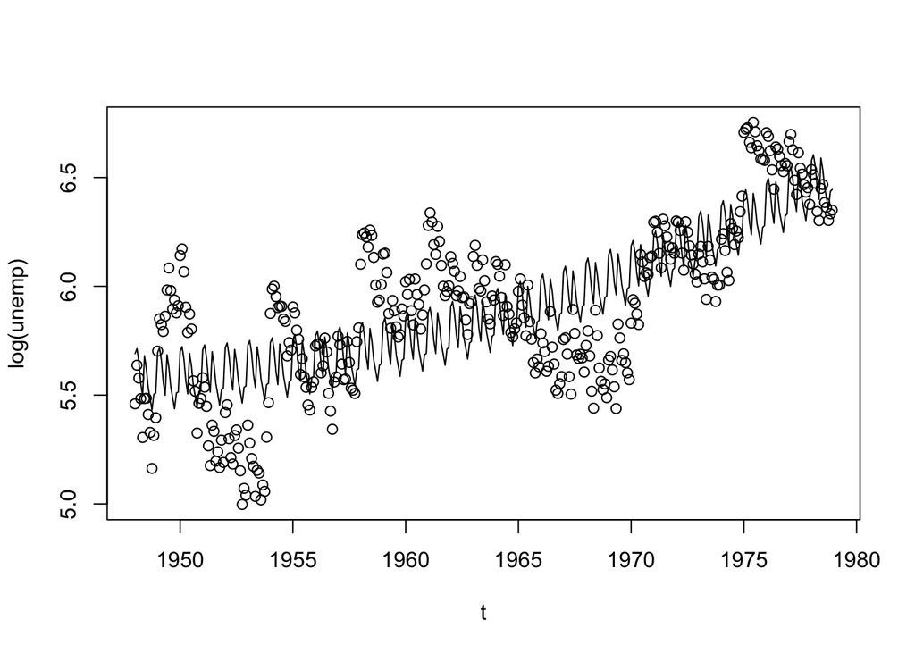

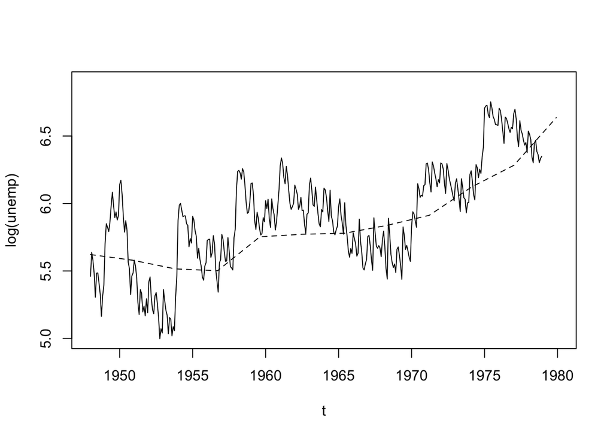

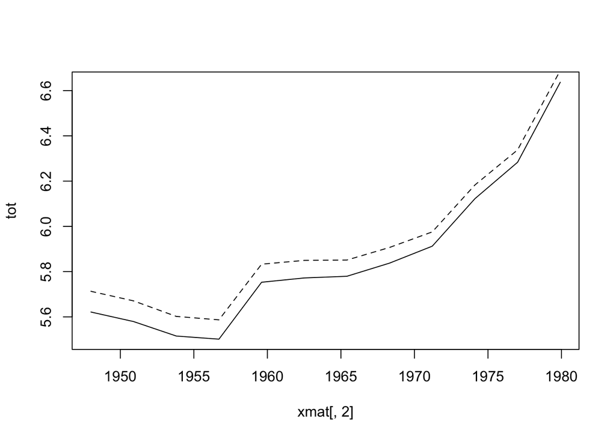

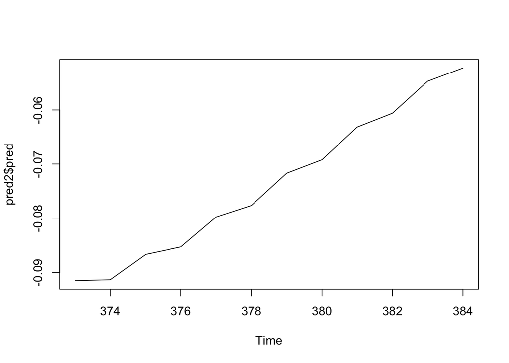

Using an ARMA(3,2) model with seasonal differencing results in the following forecast for the next year

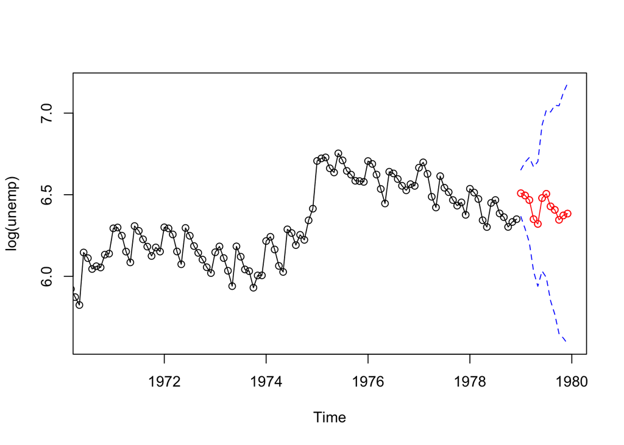

4.1)

1. Changing n from 100 to 128 reduces the frequencies in x1, x2 and x3 from 0.06, 0.10, 0.40 to 0.046875, 0.078125 and 0.3125, respectively. The increase in n doesn’t affect how the plots of x1, x2, and x3 look, but it does change the plot of their sum.

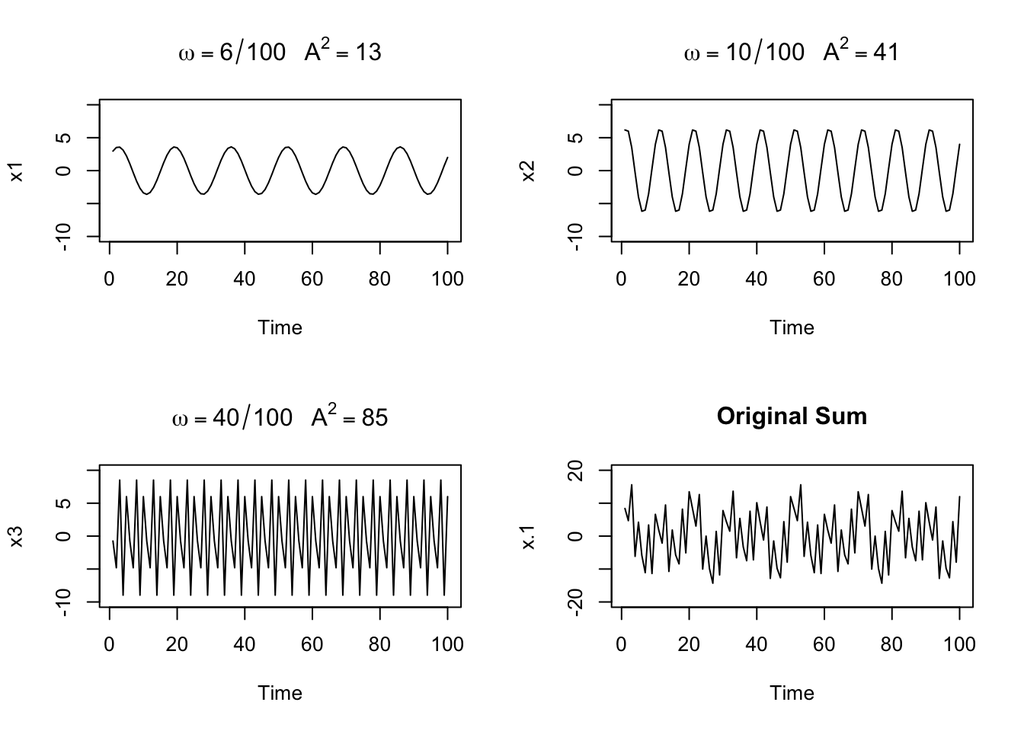

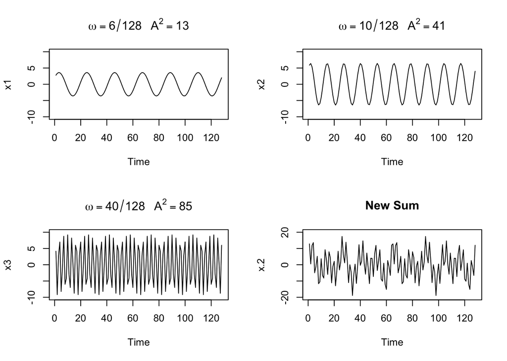

2. The change in frequency is present in the scaled periodograms. The old periodogram on top shows spikes corresponding to the original frequencies, 0.06, 0.10 and 0.40, while the new periodogram shows spikes at the new frequencies, 0.046875, 0.078125 and 0.3125. Overall, increasing N reduced the frequencies which is reflected in the 3 spikes shifted to lower frequencies in the new periodogam relative to the old periodogram.

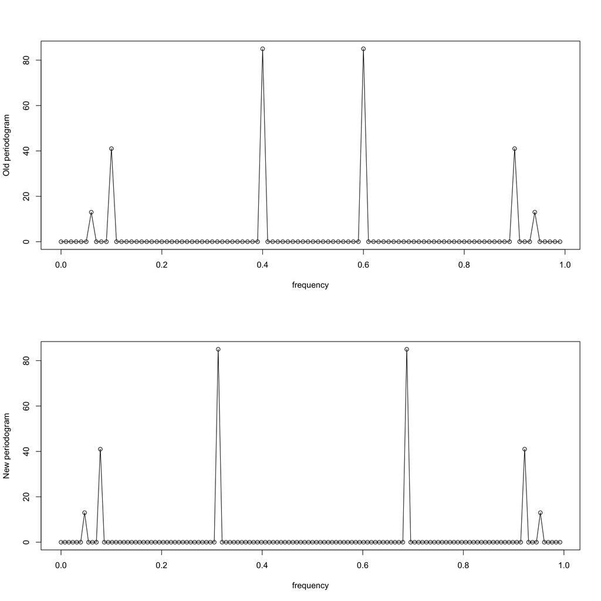

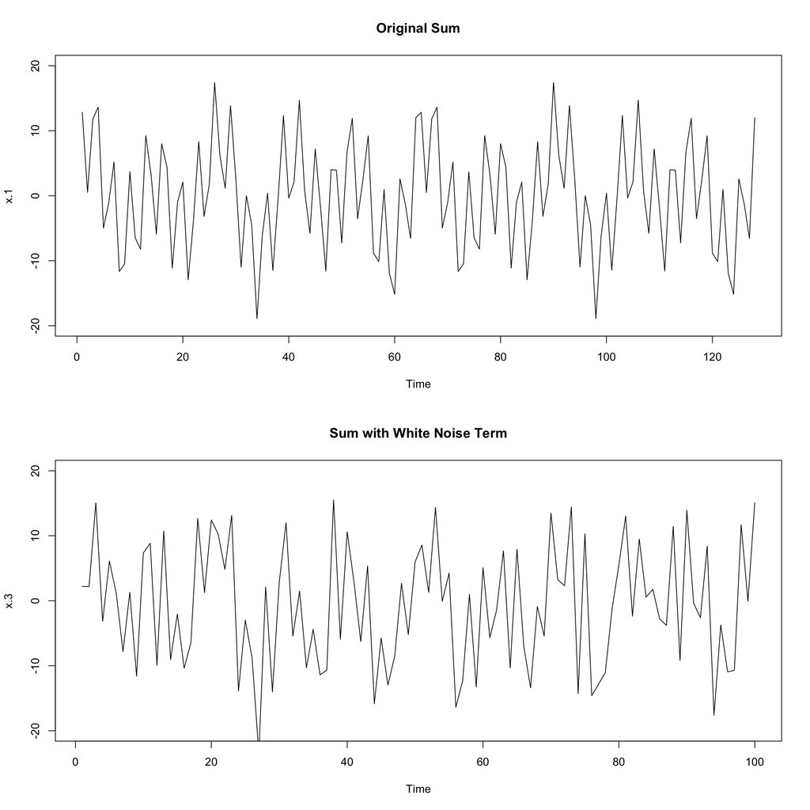

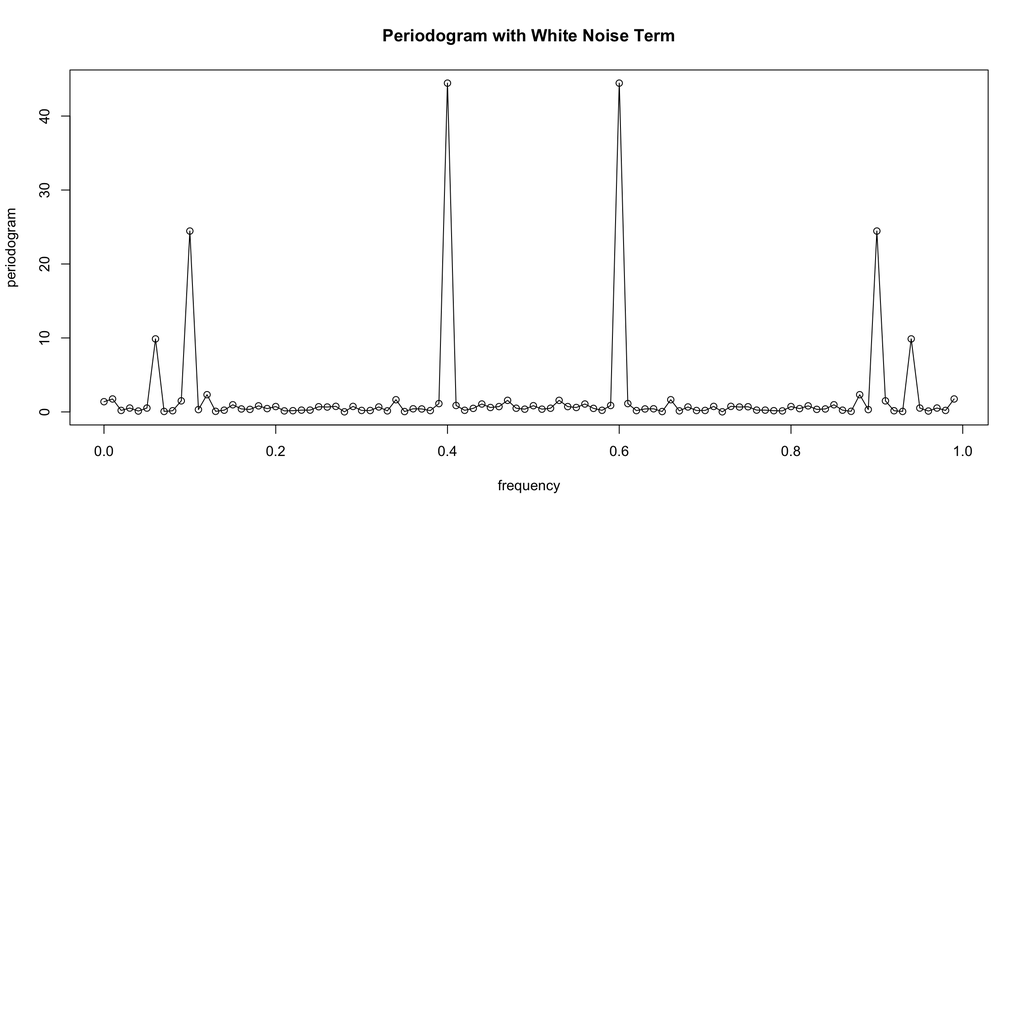

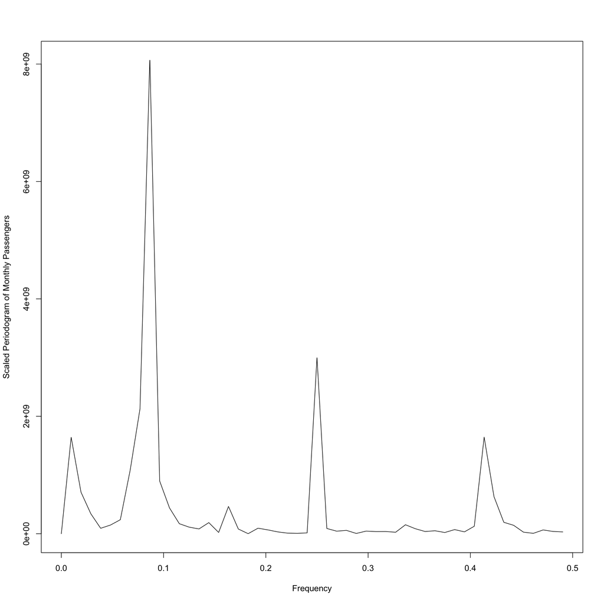